# Practical 6 Supervised learning: Classification 2

# Q14

**Create a classification tree model where the splits continue until all the observations have been classified. Call this model `iris_tree_full_mod.` Plot this model using `rpart.plot()`. Do you expect this model to perform better or worse on new Irises?**

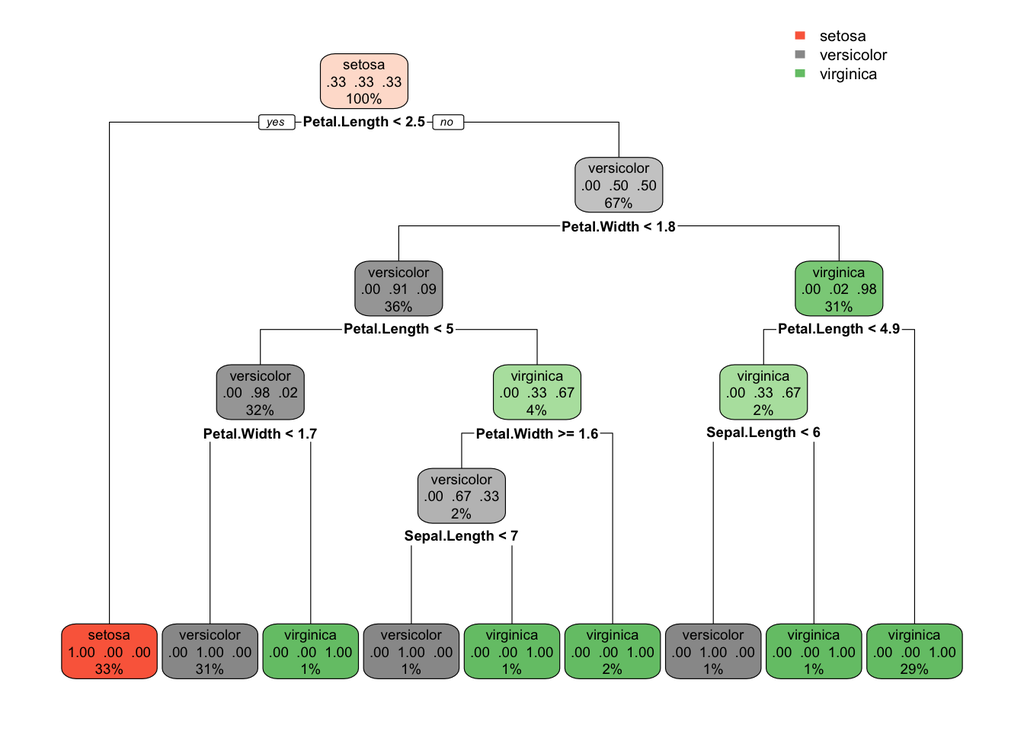

```r
iris_tree_full_mod <- rpart(Species ~ ., data = iris,
                            control = rpart.control(minbucket = 1, cp = 0))

rpart.plot(iris_tree_full_mod)
```

# Q15

**Use the function `randomForest()` to create a random forest model on the iris dataset. Use the function `importance()` on this model and create a bar plot of variable importance. Does this agree with your expectations? How well does the random forest model perform compared to the `lda_iris` model?**

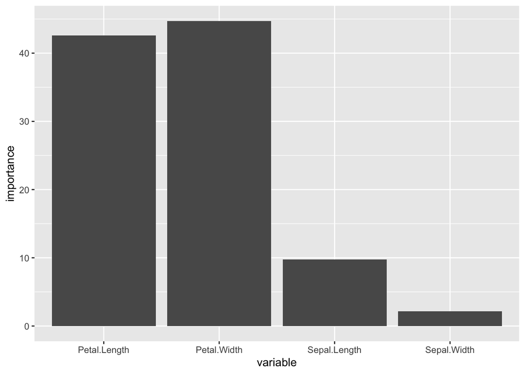

```r
random_forest <- randomForest(Species ~ ., data = iris)

data.frame(
   importance = unname(importance(random_forest)),
   variable = rownames(importance(random_forest))
) %>%
   ggplot(aes(x = variable, y = importance)) +
   geom_col()
```

```r
random_forest
```

```
##
## Call:
##  randomForest(formula = Species ~ ., data = iris)
##                Type of random forest: classification
##                      Number of trees: 500
## No. of variables tried at each split: 2
##
##         OOB estimate of  error rate: 4%
## Confusion matrix:
##            setosa versicolor virginica class.error
## setosa         50          0         0        0.00
## versicolor      0         47         3        0.06
## virginica       0          3        47        0.06
```

```r
# lda model performs slighty better (in sample though)
```